# Censo Nacional de Comisarías 2017

Análisis de Infraestructura y Equipamiento

Vilma Romero

06/12/2018

# Introducción

Los datos que vamos a analizar provienen del *VI Censo Nacional de Comisarías* realizado en el año 2017 por el [**Instituto Nacional de Estadística e Informática**](https://www.inei.gob.pe). El objetivo primordial de dicho censo fue conocer mejor la infraestructura y equipamiento con el que cuentan los locales donde funcionan las Comisarías de la Policía Nacional del Perú. Entre las principales características a evaluar fueron:

- Ámbito jurisdiccional de la comisaría
- Número de policías asignados
- Labor de cada policiía asignado
- Accesorios de trabajo
- Planes operativos y de emergencia

Pueden conocer más sobre el ánalisis final de este censo en la publicación oficial del INEI: [**PERÚ: VI CENSO NACIONAL DE COMISARÍAS 2017, Resultados Definitivos**](https://www.inei.gob.pe/media/MenuRecursivo/publicaciones_digitales/Est/Lib1528/index.html).

# Análisis Descriptivo

## Lectura de Datos

El archivo con la información descargada del INEI se encuentra en la carpeta datos y tiene por nombre *CensoComisarias.sav*. El formato de este archivo corresponde a bases de datos registradas en el software SPSS, por lo que, se debe importar al R haciendo uso del paquete `foreign`.

```r
# install.packages("foreign")
library(foreign)
datos <-  read.spss("datos/CensoComisarias.sav", to.data.frame=TRUE)
```

Veamos cuanta información tenemos,

```r
dim(datos)
```

```
## [1] 1495  280
```

Existen 1495 registros y 280 variables.

Ahora, veamos un pequeño extracto de los datos.

```r
datos[1:5, 4:6]
```

```
##                               NOMBREDI               INF109    INF109A
## 1 RUPA-RUPA                            De 40001 - 80000 Hab  Distrital
## 2 MARIANO DAMASO BERAUN                 De 5000 - 10000 Hab  Distrital
## 3 JOSE CRESPO Y CASTILLO               De 20001 - 40000 Hab  Distrital
## 4 TOCACHE                               De 5000 - 10000 Hab Provincial
## 5 NUEVO PROGRESO                        De 5000 - 10000 Hab  Distrital
```

```r
knitr::kable(datos[1:5, 4:6])
```

| NOMBREDI | INF109 | INF109A |
| --- | --- | --- |
| RUPA-RUPA | De 40001 - 80000 Hab | Distrital |
| MARIANO DAMASO BERAUN | De 5000 - 10000 Hab | Distrital |
| JOSE CRESPO Y CASTILLO | De 20001 - 40000 Hab | Distrital |
| TOCACHE | De 5000 - 10000 Hab | Provincial |
| NUEVO PROGRESO | De 5000 - 10000 Hab | Distrital |

## Jurisdicción

### Alcance de Jurisdicción

```r
cuadro1 <- as.data.frame(table(datos$INF109))
cuadro2 <- as.data.frame(prop.table(table(datos$INF109)))

names(cuadro1) <- c("Categoría", "Frecuencia")
cuadro1$Porcentaje <- cuadro2$Freq

knitr::kable(cuadro1)
```

| Categoría | Frecuencia | Porcentaje |
| --- | --- | --- |
| Menos de 5000 Hab | 288 | 0.1926421 |
| De 5000 - 10000 Hab | 329 | 0.2200669 |
| De 10001 - 20000 Hab | 290 | 0.1939799 |
| De 20001 - 40000 Hab | 248 | 0.1658863 |
| De 40001 - 80000 Hab | 196 | 0.1311037 |
| De 80001 a más Hab | 144 | 0.0963211 |

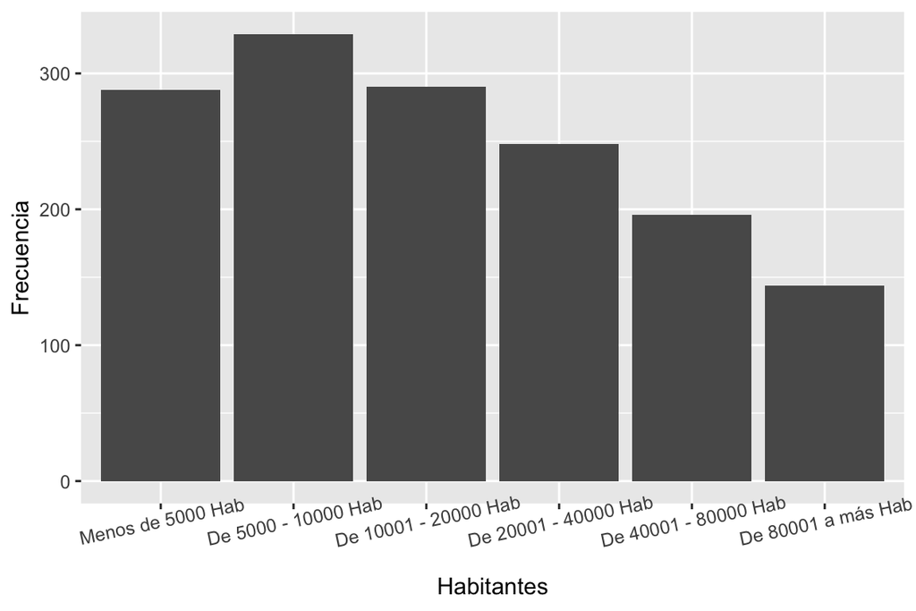

Alcance de Jurisdicción de las Comisarías

```r
library(ggplot2)
ggplot(datos, mapping = aes(x = INF109)) +
  geom_bar() +
  xlab("Habitantes") + ylab("Frecuencia") +
  theme(axis.text.x = element_text(angle = 12))
```

### Tipo de Jurisdicción

```r
knitr::kable(table(datos$INF109A), col.names = c("Categoría", "Frecuencia"))
```

| Categoría | Frecuencia |
| --- | --- |
| Nacional | 2 |
| Regional | 29 |
| Provincial | 139 |
| Distrital | 1241 |
| Otros | 84 |

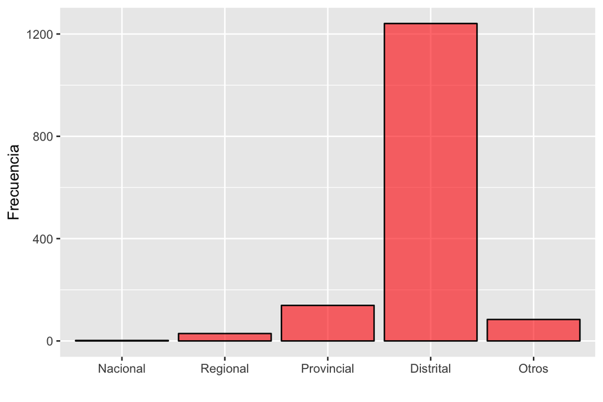

Tipo de Jurisdicción de las Comisarías

```r
library(ggplot2)
ggplot(datos, mapping = aes(x = INF109A)) +
  geom_bar(color = "black", fill = "red", alpha = 0.6) +
  xlab("") + ylab("Frecuencia")
```

Estos gráficos fueron elaborados con el paquete `ggplot2` desarrollado por Wickham (2009). Además, el reporte fue generado usando `rmarkdown`. Pueden aprender más en el libro de Xie, Allaire, and Grolemund (2016).

Wickham, Hadley. 2009. *ggplot2: Elegant Graphics for Data Analysis*. Springer.

Xie, Yihui, J.J. Allaire, and Garrett Grolemund. 2016. *R Markdown: The Definitive Guide*. 1st ed. Chapman; Hall/CRC.